# PREDICTIVE MODELLING USING REGRESSION

### Group 7

- Jibin George: **0832593**
- Jibin Kuruppassery Sebastian: **0829897**
- Kailas Krishnan Radhakrishnan Sudhadevi: **0850313**
- Kirangi Ravindrabhai Jadav: **0829522**
- Nilkumar Ghanshyambhai Patel: **0837725**

### Dataset Source

The Telco customer churn dataset used in this project was taken from Kaggle. The dataset contains information about a fictional telco company that provided home phone and Internet services to 7043 customers in California. It indicates which customers have left, stayed, or signed up for their service. Multiple important demographics are included for each customer, as well as a Satisfaction Score, Churn Score, and Customer Lifetime Value (CLTV) index.

[*Dataset Link*](https://www.kaggle.com/datasets/ylchang/telco-customer-churn-1113)

### Data Dictionary

Customer ID: Unique identifier for each customer

Count : Count of the customer

- 1

Country : Country each customer is located in

- United States

State : State each customer is located in

- California

City : City each customer is located in

Zip Code : Postal code associated with each customer's location

Lat Long : Geographic coordinates of each customer's location

Latitude : Latitude value of the location

Longitude : Longitude value of the location

Gender : Gender of the customer

- Male
- Female

Senior Citizen : Is the customer a senior citizen?

- No
- Yes

Partner : Does the customer have a partner?

- No
- Yes

Dependents : Does the customer have dependents?

- No
- Yes

Tenure Months : Number of months the customer has been with the company

Phone Service : Does the customer have phone service?

- No
- Yes

Multiple Lines : Does the customer have multiple phone lines?

- No phone service
- No
- Yes

Internet Service : Type of internet service opted by the customer

- DSL
- Fiber optic
- No

Online Security : Does the customer have online security?

- No internet service
- No
- Yes

Online Backup : Does the customer have online backup?

- No internet service
- No
- Yes

Device Protection : Does the customer have device protection?

- No internet service
- No
- Yes

Tech Support : Does the customer have tech support?

- No internet service
- No
- Yes

Streaming TV : Does the customer have streaming TV service?

- No internet service
- No
- Yes

Streaming Movies : Does the customer have streaming movie service?

- No internet service
- No
- Yes

Contract : Type of contract the customer has

- Month-to-month
- One-year
- Two-year

Paperless Billing : Has the customer opted for paperless billing?

- No
- Yes

Payment Method : Method of payment the customer uses

- Bank transfer (automatic)
- Credit card (automatic)
- Electronic check
- Mailed check

Monthly Charges : Amount charged to the customer each month

Total Charges : Total amount charged to the customer over their tenure

Churn Label : Whether the customer has churned?

- No
- Yes

Churn Value : Binary value for churn label

- 0 : No
- 1 : Yes

Churn Score : Percentage probability of churning

CLTV [Customer Lifetime Value] : Average revenue that can be generated from the customer over entire lifetime of their account

Churn Reason : Reason for churning

*Source : https://www.kaggle.com/datasets/ylchang/telco-customer-churn-1113?rvi=1*

**Required Libraries**

```python
import pandas as pd
import numpy as np

import matplotlib.pyplot as plt
import seaborn as sns
sns.set()

import statsmodels.api as sm
import statsmodels.formula.api as smf

from scipy.stats import probplot

from sklearn.model_selection import train_test_split
from sklearn.metrics import mean_absolute_error, mean_squared_error, r2_score

pd.set_option('display.max_columns', None)

import warnings
warnings.filterwarnings("ignore")
```

```python
# Importing the dataset
df = pd.read_csv('Telco_customer_churn.csv')
data = df.copy()
```

```python
# Shape of the dataset
print(f"Shape {data.shape}")
```

```
Shape (7043, 33)
```

```python
data.sample(10, random_state = 42)
```

|  | CustomerID | Count | Country | State | City | Zip Code | Lat Long | Latitude | Longitude | Gender | Senior Citizen | Partner | Dependents | Tenure Months | Phone Service | Multiple Lines | Internet Service | Online Security | Online Backup | Device Protection | Tech Support | Streaming TV | Streaming Movies | Contract | Paperless Billing | Payment Method | Monthly Charges | Total Charges | Churn Label | … |
| --- | --- | --- | --- | --- | --- | --- | --- | --- | --- | --- | --- | --- | --- | --- | --- | --- | --- | --- | --- | --- | --- | --- | --- | --- | --- | --- | --- | --- | --- | --- |
| 185 | 2189-WWOEW | 1 | United States | California | Keene | 93531 | 35.214982, -118.59049 | 35.214982 | -118.590490 | Female | No | No | No | 15 | Yes | No | Fiber optic | No | Yes | No | No | No | Yes | Month-to-month | Yes | Bank transfer (automatic) | 85.90 | 1269.55 | Yes | … |
| 2715 | 2446-ZKVAF | 1 | United States | California | Stockton | 95207 | 38.002125, -121.324979 | 38.002125 | -121.324979 | Male | No | Yes | No | 18 | Yes | Yes | DSL | No | Yes | No | No | No | No | Month-to-month | No | Credit card (automatic) | 56.80 | 1074.65 | No | … |
| 3825 | 4986-MXSFP | 1 | United States | California | San Leandro | 94579 | 37.687264, -122.15728 | 37.687264 | -122.157280 | Female | No | No | No | 2 | Yes | No | No | No internet service | No internet service | No internet service | No internet service | No internet service | No internet service | Month-to-month | Yes | Mailed check | 20.00 | 40.9 | No | … |
| 1807 | 5868-YWPDW | 1 | United States | California | Sherman Oaks | 91423 | 34.146957, -118.432138 | 34.146957 | -118.432138 | Male | Yes | Yes | No | 6 | Yes | No | Fiber optic | No | Yes | No | No | No | Yes | Month-to-month | Yes | Electronic check | 84.20 | 519.15 | Yes | … |
| 132 | 9412-GHEEC | 1 | United States | California | Murrieta | 92563 | 33.581045, -117.14719 | 33.581045 | -117.147190 | Male | No | No | No | 40 | Yes | Yes | Fiber optic | No | No | Yes | Yes | Yes | Yes | Month-to-month | No | Bank transfer (automatic) | 104.80 | 4131.95 | Yes | … |
| 1263 | 3389-YGYAI | 1 | United States | California | Princeton | 95970 | 39.424957, -122.039307 | 39.424957 | -122.039307 | Female | Yes | No | No | 8 | Yes | Yes | Fiber optic | No | Yes | Yes | No | Yes | Yes | Month-to-month | Yes | Electronic check | 105.50 | 829.55 | Yes | … |
| 3732 | 4927-WWOOZ | 1 | United States | California | Pacific Grove | 93950 | 36.618337, -121.926417 | 36.618337 | -121.926417 | Male | No | Yes | No | 2 | Yes | Yes | Fiber optic | No | No | Yes | No | Yes | No | Month-to-month | Yes | Electronic check | 91.45 | 171.45 | No | … |
| 1672 | 4558-FANTW | 1 | United States | California | Fair Oaks | 95628 | 38.652065, -121.25441 | 38.652065 | -121.254410 | Female | No | Yes | No | 17 | Yes | No | Fiber optic | Yes | No | No | Yes | Yes | No | Month-to-month | No | Electronic check | 91.85 | 1574.45 | Yes | … |
| 811 | 6032-IGALN | 1 | United States | California | Granite Bay | 95746 | 38.749466, -121.184196 | 38.749466 | -121.184196 | Female | No | No | No | 1 | No | No phone service | DSL | No | No | No | No | No | No | Month-to-month | Yes | Mailed check | 25.10 | 25.1 | Yes | … |
| 2526 | 3523-BRGUW | 1 | United States | California | Los Altos | 94022 | 37.349546, -122.134356 | 37.349546 | -122.134356 | Male | Yes | No | No | 26 | Yes | No | No | No internet service | No internet service | No internet service | No internet service | No internet service | No internet service | One year | No | Credit card (automatic) | 19.30 | 504.2 | No | … |

```python
# Descriptive Statistics for Continuous Variables
data.describe()
```

|  | Count | Zip Code | Latitude | Longitude | Tenure Months | Monthly Charges | Churn Value | Churn Score | CLTV |
| --- | --- | --- | --- | --- | --- | --- | --- | --- | --- |
| count | 7043.0 | 7043.000000 | 7043.000000 | 7043.000000 | 7043.000000 | 7043.000000 | 7043.000000 | 7043.000000 | 7043.000000 |
| mean | 1.0 | 93521.964646 | 36.282441 | -119.798880 | 32.371149 | 64.761692 | 0.265370 | 58.699418 | 4400.295755 |
| std | 0.0 | 1865.794555 | 2.455723 | 2.157889 | 24.559481 | 30.090047 | 0.441561 | 21.525131 | 1183.057152 |
| min | 1.0 | 90001.000000 | 32.555828 | -124.301372 | 0.000000 | 18.250000 | 0.000000 | 5.000000 | 2003.000000 |
| 25% | 1.0 | 92102.000000 | 34.030915 | -121.815412 | 9.000000 | 35.500000 | 0.000000 | 40.000000 | 3469.000000 |
| 50% | 1.0 | 93552.000000 | 36.391777 | -119.730885 | 29.000000 | 70.350000 | 0.000000 | 61.000000 | 4527.000000 |
| 75% | 1.0 | 95351.000000 | 38.224869 | -118.043237 | 55.000000 | 89.850000 | 1.000000 | 75.000000 | 5380.500000 |
| max | 1.0 | 96161.000000 | 41.962127 | -114.192901 | 72.000000 | 118.750000 | 1.000000 | 100.000000 | 6500.000000 |

**Observations**

- The feature `Count` is having only one value which is `1`.
- `Churn Value` is a feature that is a numerical representation of the categorical column `Churn Label`. Therefore `Churn Value` should be a categorical value but is taken as numerical here.

```python
# Summary of Categorical Variables
data.describe(include = 'object').T
```

|  | count | unique | top | freq |
| --- | --- | --- | --- | --- |
| CustomerID | 7043 | 7043 | 3668-QPYBK | 1 |
| Country | 7043 | 1 | United States | 7043 |
| State | 7043 | 1 | California | 7043 |
| City | 7043 | 1129 | Los Angeles | 305 |
| Lat Long | 7043 | 1652 | 33.964131, -118.272783 | 5 |
| Gender | 7043 | 2 | Male | 3555 |
| Senior Citizen | 7043 | 2 | No | 5901 |
| Partner | 7043 | 2 | No | 3641 |
| Dependents | 7043 | 2 | No | 5416 |
| Phone Service | 7043 | 2 | Yes | 6361 |
| Multiple Lines | 7043 | 3 | No | 3390 |
| Internet Service | 7043 | 3 | Fiber optic | 3096 |
| Online Security | 7043 | 3 | No | 3498 |
| Online Backup | 7043 | 3 | No | 3088 |
| Device Protection | 7043 | 3 | No | 3095 |
| Tech Support | 7043 | 3 | No | 3473 |
| Streaming TV | 7043 | 3 | No | 2810 |
| Streaming Movies | 7043 | 3 | No | 2785 |
| Contract | 7043 | 3 | Month-to-month | 3875 |
| Paperless Billing | 7043 | 2 | Yes | 4171 |
| Payment Method | 7043 | 4 | Electronic check | 2365 |
| Total Charges | 7043 | 6531 | 20.2 | 11 |
| Churn Label | 7043 | 2 | No | 5174 |
| Churn Reason | 1869 | 20 | Attitude of support person | 192 |

**Observations**

- The data is taken from California, United States. Hence there is only a single value in the `Country` and `State` column.
- `Total Charges` should be a numerical column but is considered as an object.
- `City` is having more than 1000 unique values.

```python
# Converting column names
data.columns = [i.lower().replace(' ', '_') for i in data.columns]
```

**Dropping Redundant Columns**

- `Customer ID` is unique for each of the observation and hence is not a good feature for model building
- `Count`, `Country` and `State` are having only a single value and hence these features are also not relevant for model building.
- `City` is having more than 1000 unique values which may be a problem when encoding categorical variables.
- `Lat Long` is an array representing the Latitude and Longitude of the customer. Since these values are already present in the data we can remove this column.
- Since we are trying to predict the `Churn Score` all other values that are same as this feature [`Churn Label`, `Churn Value`, `CLTV`, `Churn Reason`] should be removed.

```python
# Dropping above mentioned columns
data.drop(columns = ["customerid", "count", "country", "state", "city", "lat_long", "churn_label", "churn_value", "cltv", "churn_reason"], inplace = True)
```

**Missing Value Treatment**

```python
data.isnull().sum()
```

```
zip_code             0
latitude             0
longitude            0
gender               0
senior_citizen       0
partner              0
dependents           0
tenure_months        0
phone_service        0
multiple_lines       0
internet_service     0
online_security      0
online_backup        0
device_protection    0
tech_support         0
streaming_tv         0
streaming_movies     0
contract             0
paperless_billing    0
payment_method       0
monthly_charges      0
total_charges        0
churn_score          0
dtype: int64
```

There are no missing values present in the dataset.

**Type Casting**

```python
try:
    data['total_charges'].astype('float')
except:
    print('There are values in the column that are not numerical.')
```

```
There are values in the column that are not numerical.
```

```python
# Identifying the anomaly in the feature.
anomaly = []
for i in data['total_charges']:
    try:
        float(i)
    except ValueError:
        if i not in anomaly:
            anomaly.append(i)
print(anomaly)
```

```
[' ']
```

**Observations**

- May be these string values represent 0 charges
- The definition of total_charges is : Total amount charged to the customer over their tenure
- Checking with tenture to confirm the assumption

```python
data['tenure_months'][data['total_charges'] == ' ']
```

```
2234    0
2438    0
2568    0
2667    0
2856    0
4331    0
4687    0
5104    0
5719    0
6772    0
6840    0
Name: tenure_months, dtype: int64
```

The assumption was correct. Those were the customers who didn't even use the telcom services for one month.

```python
# Replacing the string with 0 charges and converting the column to float datatype
data['total_charges'] = data['total_charges'].map(lambda x: 0 if x == ' ' else x)
data['total_charges'] = data['total_charges'].astype('float')
```

**Simple Linear Regression**

The target variable choosen here is `Churn Score`. The feature represents the probability score in percentage of the chances of a customer to churn.

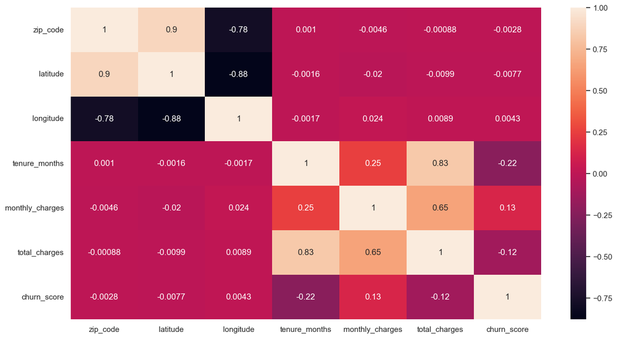

```python
# Correlation Map
num_cols = data.dtypes[data.dtypes != 'object'].index

plt.figure(figsize = (15,8))
sns.heatmap(data[num_cols].corr(), annot = True)
plt.show()
```

**Observations**

- `Tenure Months` and `Monthly Charges` are the features that are having a reasonable correlation with `Churn Score`.

**Model 1 -- Churn Score ~ Tenure Months**

```python
x_1 = data['tenure_months']
y_1 = data['churn_score']
```

```python
x_1_train, x_1_test, y_1_train, y_1_test = train_test_split(x_1, y_1, test_size = 0.2, random_state = 42)
```

```python
X_1 = sm.add_constant(x_1_train)
model_1 = sm.OLS(y_1_train,X_1).fit()
model_1.summary()
```

OLS Regression Results

| Dep. Variable: | churn_score | R-squared: | 0.050 |
| --- | --- | --- | --- |
| Model: | OLS | Adj. R-squared: | 0.050 |
| Method: | Least Squares | F-statistic: | 296.7 |
| Date: | Thu, 07 Dec 2023 | Prob (F-statistic): | 7.73e-65 |
| Time: | 00:01:18 | Log-Likelihood: | -25169. |
| No. Observations: | 5634 | AIC: | 5.034e+04 |
| Df Residuals: | 5632 | BIC: | 5.036e+04 |
| Df Model: | 1 |  |  |
| Covariance Type: | nonrobust |  |  |

|  | coef | std err | t | P>\|t\| | [0.025 | 0.975] |
| --- | --- | --- | --- | --- | --- | --- |
| const | 64.8005 | 0.465 | 139.218 | 0.000 | 63.888 | 65.713 |
| tenure_months | -0.1971 | 0.011 | -17.225 | 0.000 | -0.220 | -0.175 |

| Omnibus: | 924.637 | Durbin-Watson: | 1.991 |
| --- | --- | --- | --- |
| Prob(Omnibus): | 0.000 | Jarque-Bera (JB): | 226.166 |
| Skew: | -0.153 | Prob(JB): | 7.74e-50 |
| Kurtosis: | 2.067 | Cond. No. | 67.4 |

Notes:  
[1] Standard Errors assume that the covariance matrix of the errors is correctly specified.

The Equation is : $ Y = 64.8005 - 0.1971 * Tenure Months$

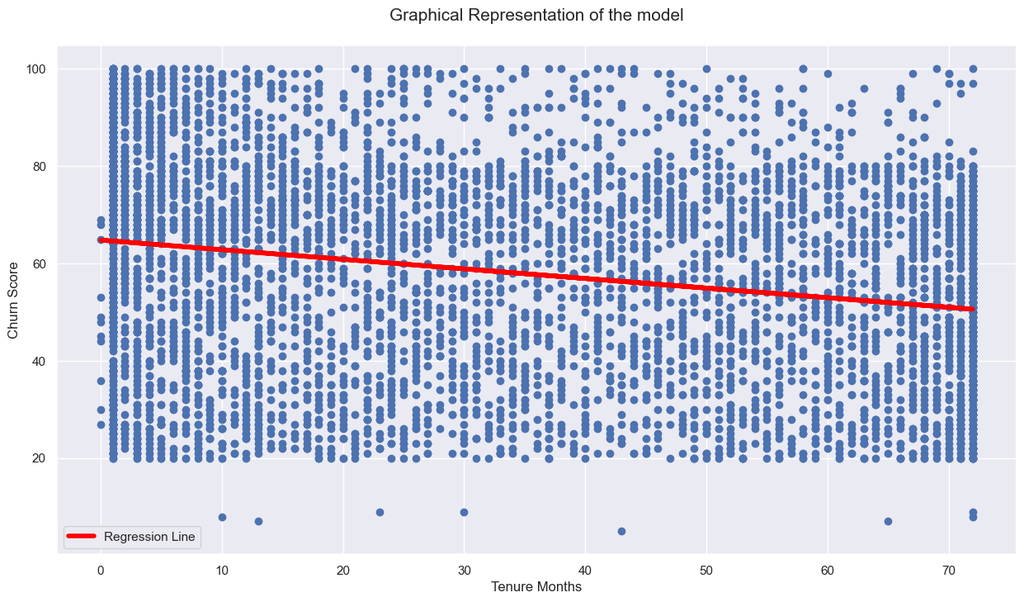

```python
# Graphical Representation of the model
plt.figure(figsize = (15,8))
plt.scatter(x_1_train, y_1_train)
# Regression Line
y_hat = 64.8005 - 0.1971 * x_1_train
fig = plt.plot(x_1_train, y_hat, lw = 4, c = 'red', label = 'Regression Line')
plt.title('Graphical Representation of the model\n', fontsize = 15)
plt.xlabel('Tenure Months')
plt.ylabel('Churn Score')
plt.legend()
plt.show()
```

**Observations**

- The correlation between `Tenure months` and `Churn Score` is pretty low and hence the spread.

**Slope**

- Slope of the model tells us that as each month increases, the churn score will decrease by 0.1971 units, starting at 64.
- This illustrates that as tenure months increase, the chances of customers staying with the company increase.

**Model Assessment**

```python
model_1_metrics = pd.DataFrame({
    "MSE" : [mean_squared_error(y_1_train, model_1.predict(sm.add_constant(x_1_train))), mean_squared_error(y_1_test, model_1.predict(sm.add_constant(x_1_test)))],
    "RMSE" : [(mean_squared_error(y_1_train, model_1.predict(sm.add_constant(x_1_train))))**0.5, (mean_squared_error(y_1_test, model_1.predict(sm.add_constant(x_1_test))))**0.5],
    "R^2" : [r2_score(y_1_train, model_1.predict(sm.add_constant(x_1_train))), r2_score(y_1_test, model_1.predict(sm.add_constant(x_1_test)))],
    "MAE" : [mean_absolute_error(y_1_train, model_1.predict(sm.add_constant(x_1_train))), mean_absolute_error(y_1_test, model_1.predict(sm.add_constant(x_1_test)))]
}, index = ["Train", "Test"]).T

model_1_metrics
```

|  | Train | Test |
| --- | --- | --- |
| MSE | 444.453014 | 421.660937 |
| RMSE | 21.082054 | 20.534384 |
| R^2 | 0.050044 | 0.048528 |
| MAE | 17.930320 | 17.423233 |

**Observations**

- The model seems to have relatively high errors (MSE, RMSE, MAE) on both training and testing sets.
- The $R^2$ values are low, indicating that the model doesn't explain much of the variance in the target variable.
- The metric we choose here is $R^2$.
- $R^2$ explains the total variance explained by the model. So $R^2$ helps us in understanding whether the variability of the data can be explained by the created model.
- According to the metric the model is not good enough in predicting churn score. This suggests that we should consider more features to improve the models performance.

**Model Diagnostics**

```python
residuals_model_1 = pd.DataFrame({'Actual': y_1_train,
                               'Predicted': model_1.fittedvalues,
                               'Residuals': model_1.resid})

residuals_model_1.reset_index(drop = True, inplace = True)
residuals_model_1.head(10)
```

|  | Actual | Predicted | Residuals |
| --- | --- | --- | --- |
| 0 | 28 | 50.806678 | -22.806678 |
| 1 | 75 | 61.646998 | 13.353002 |
| 2 | 60 | 58.493450 | 1.506550 |
| 3 | 85 | 60.070224 | 24.929776 |
| 4 | 43 | 60.858611 | -17.858611 |
| 5 | 77 | 64.406352 | 12.593648 |
| 6 | 73 | 54.551516 | 18.448484 |
| 7 | 20 | 57.507967 | -37.507967 |
| 8 | 77 | 56.719580 | 20.280420 |
| 9 | 46 | 53.368935 | -7.368935 |

**Linearity**

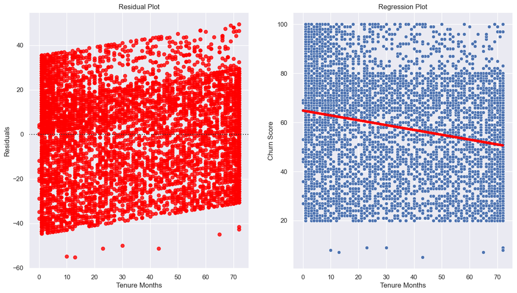

```python
fig, (ax1, ax2) = plt.subplots(nrows = 1, ncols = 2, figsize = (15,8))
sns.residplot(x_1_train, y_1_train, color = 'red', ax = ax1)
ax1.set_title("Residual Plot")
ax1.set_xlabel('Tenure Months')
ax1.set_ylabel('Residuals')

sns.scatterplot(x_1_train, y_1_train, ax = ax2)
ax2.plot(x_1_train, y_hat, lw = 4, c = 'red', label = 'Regression Line')
ax2.set_title("Regression Plot")
ax2.set_xlabel('Tenure Months')
ax2.set_ylabel('Churn Score')
plt.show()
```

**Observations**

- There is no linear relationship between tenure months and churn score.

**Nearly Normal Residuals**

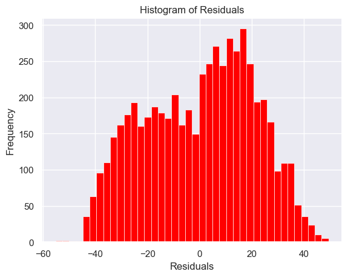

```python
plt.hist(residuals_model_1['Residuals'], bins = 40, linewidth = 0.5, color = 'red')
plt.title('Histogram of Residuals')
plt.xlabel('Residuals')
plt.ylabel('Frequency')
plt.show()
```

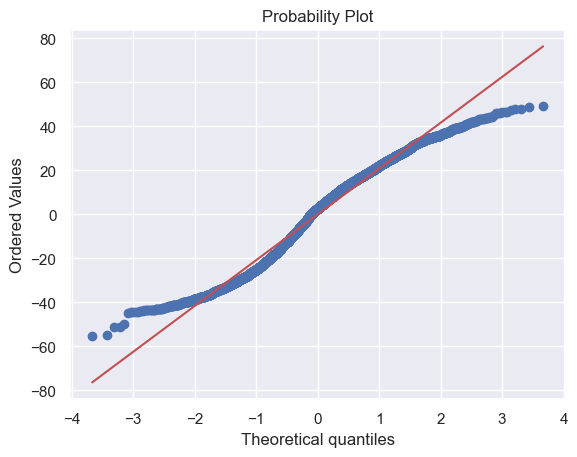

```python
probplot(residuals_model_1['Residuals'], plot = plt)
plt.show()
```

**Observations**

- From both the plots we can clarify that residuals are not normally distributed.

**Constant Variability**

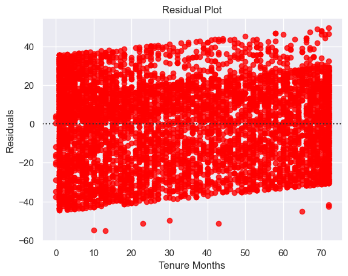

```python
sns.residplot(x_1_train, y_1_train, color = 'red')
plt.title("Residual Plot")
plt.xlabel('Tenure Months')
plt.ylabel('Residuals')
plt.show()
```

**Observations**

- There is slanting to the left visible in the residual plot.
- Since there is a sland we can confirm that the constant variability is not met.

**Model 2 -- Churn Score ~ Monthly Charges**

```python
x_2 = data['monthly_charges']
y_2 = data['churn_score']
```

```python
x_2_train, x_2_test, y_2_train, y_2_test = train_test_split(x_2, y_2, test_size = 0.2, random_state = 42)
```

```python
X_2 = sm.add_constant(x_2_train)
model_2 = sm.OLS(y_2_train,X_2).fit()
model_2.summary()
```

OLS Regression Results

| Dep. Variable: | churn_score | R-squared: | 0.019 |
| --- | --- | --- | --- |
| Model: | OLS | Adj. R-squared: | 0.019 |
| Method: | Least Squares | F-statistic: | 108.7 |
| Date: | Thu, 07 Dec 2023 | Prob (F-statistic): | 3.16e-25 |
| Time: | 00:01:33 | Log-Likelihood: | -25260. |
| No. Observations: | 5634 | AIC: | 5.052e+04 |
| Df Residuals: | 5632 | BIC: | 5.054e+04 |
| Df Model: | 1 |  |  |
| Covariance Type: | nonrobust |  |  |

|  | coef | std err | t | P>\|t\| | [0.025 | 0.975] |
| --- | --- | --- | --- | --- | --- | --- |
| const | 52.0577 | 0.673 | 77.397 | 0.000 | 50.739 | 53.376 |
| monthly_charges | 0.0986 | 0.009 | 10.427 | 0.000 | 0.080 | 0.117 |

| Omnibus: | 1207.739 | Durbin-Watson: | 1.993 |
| --- | --- | --- | --- |
| Prob(Omnibus): | 0.000 | Jarque-Bera (JB): | 237.588 |
| Skew: | -0.095 | Prob(JB): | 2.56e-52 |
| Kurtosis: | 2.012 | Cond. No. | 168. |

Notes:  
[1] Standard Errors assume that the covariance matrix of the errors is correctly specified.

The Equation is : $Y = 52.0577 + 0.0986 * Monthly Charges$

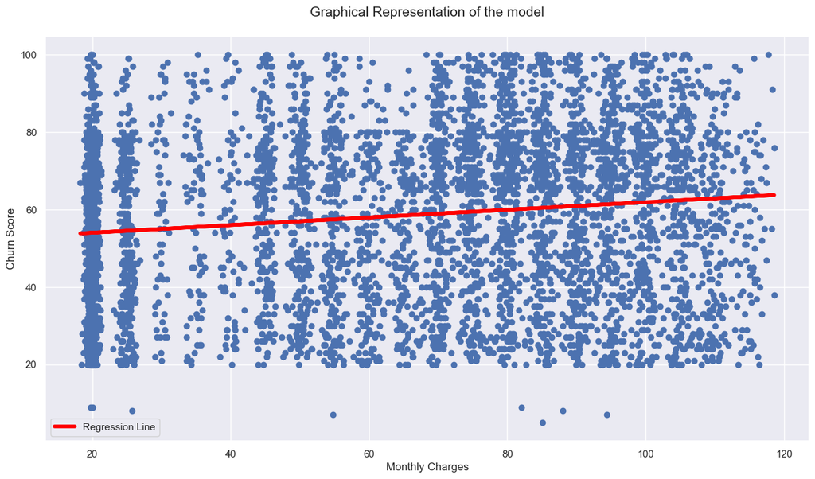

```python
# Graphical Representation of the model
plt.figure(figsize = (15,8))
plt.scatter(x_2_train, y_2_train)
# Regression Line
y_hat = 52.0577 + 0.0986 * x_2_train
fig = plt.plot(x_2_train, y_hat, lw = 4, c = 'red', label = 'Regression Line')
plt.title('Graphical Representation of the model\n', fontsize = 15)
plt.xlabel('Monthly Charges')
plt.ylabel('Churn Score')
plt.legend()
plt.show()
```

**Intercept**

- The intercept value for this model is 52.0577. Since we are trying to predict the churn score, which represents the probability score of churn, the intercept for this model is also **not a good measure for predicting**.
- The equation tells as that a minimum churn score of 52 will be assigned to all the customers by the model.
- If we give a cut-off of 50, then this model will predict that all customers will churn.

**Slope**

- Slope of the model tells us that as monthly charge increases, the churn score will increase by 0.0986 units, starting at 52.
- This illustrates that as monthly charges increase, the chances of customers leaving the company increase.

**Model Assessment**

```python
model_2_metrics = pd.DataFrame({
    "MSE" : [mean_squared_error(y_2_train, model_2.predict(sm.add_constant(x_2_train))), mean_squared_error(y_2_test, model_2.predict(sm.add_constant(x_2_test)))],
    "RMSE" : [(mean_squared_error(y_2_train, model_2.predict(sm.add_constant(x_2_train))))**0.5, (mean_squared_error(y_2_test, model_2.predict(sm.add_constant(x_2_test))))**0.5],
    "R^2" : [r2_score(y_2_train, model_2.predict(sm.add_constant(x_2_train))), r2_score(y_2_test, model_2.predict(sm.add_constant(x_2_test)))],
    "MAE" : [mean_absolute_error(y_2_train, model_2.predict(sm.add_constant(x_2_train))), mean_absolute_error(y_2_test, model_2.predict(sm.add_constant(x_2_test)))]
}, index = ["Train", "Test"]).T

model_2_metrics
```

|  | Train | Test |
| --- | --- | --- |
| MSE | 459.006195 | 439.240642 |
| RMSE | 21.424430 | 20.958069 |
| R^2 | 0.018939 | 0.008860 |
| MAE | 18.332628 | 17.881637 |

**Observations**

- The model seems to show relatively better results during the test phase due to low errors comparing to the training phase.
- The $R^2$ values are low, indicating that the model explained only a small fraction of variance in the target variable.
- The metric we choose here is $R^2$.
- According to the metric the model is not even good than the last one in predicting churn score. This suggests that we should consider more features to improve the models performance.

**Model Diagnostics**

```python
residuals_model_2 = pd.DataFrame({'Actual': y_2_train,
                               'Predicted': model_2.fittedvalues,
                               'Residuals': model_2.resid})

residuals_model_2.reset_index(drop = True, inplace = True)
residuals_model_2.head(10)
```

|  | Actual | Predicted | Residuals |
| --- | --- | --- | --- |
| 0 | 28 | 61.780988 | -33.780988 |
| 1 | 75 | 61.243816 | 13.756184 |
| 2 | 60 | 62.313232 | -2.313232 |
| 3 | 85 | 56.064294 | 28.935706 |
| 4 | 43 | 54.033881 | -11.033881 |
| 5 | 77 | 59.504167 | 17.495833 |
| 6 | 73 | 58.395325 | 14.604675 |
| 7 | 20 | 54.014169 | -34.014169 |
| 8 | 77 | 59.415459 | 17.584541 |
| 9 | 46 | 59.469669 | -13.469669 |

**Linearity**

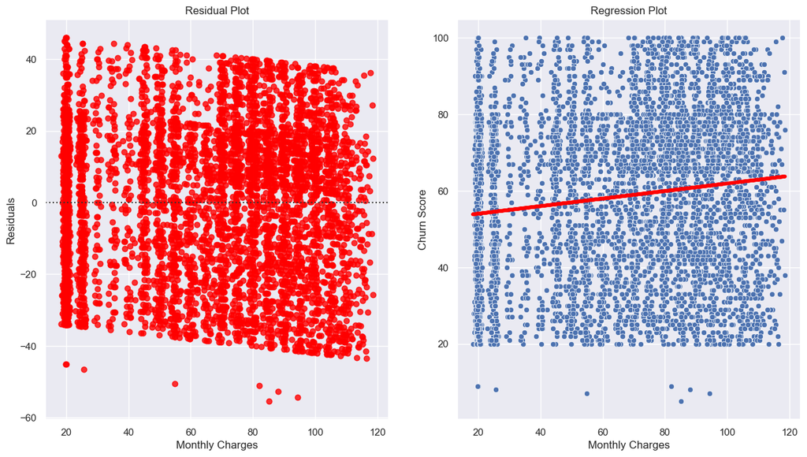

```python
fig, (ax1, ax2) = plt.subplots(nrows = 1, ncols = 2, figsize = (15,8))
sns.residplot(x_2_train, y_2_train, color = 'red', ax = ax1)
ax1.set_title("Residual Plot")
ax1.set_xlabel('Monthly Charges')
ax1.set_ylabel('Residuals')

sns.scatterplot(x_2_train, y_2_train, ax = ax2)
ax2.plot(x_2_train, y_hat, lw = 4, c = 'red', label = 'Regression Line')
ax2.set_title("Regression Plot")
ax2.set_xlabel('Monthly Charges')
ax2.set_ylabel('Churn Score')
plt.show()
```

**Nearly Normal Residuals**

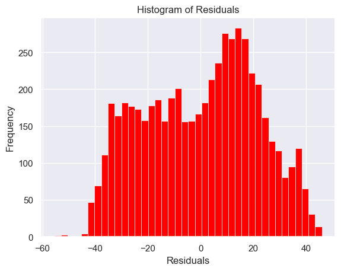

```python
plt.hist(residuals_model_2['Residuals'], bins = 40, linewidth = 0.5, color = 'red')
plt.title('Histogram of Residuals')
plt.xlabel('Residuals')
plt.ylabel('Frequency')
plt.show()
```

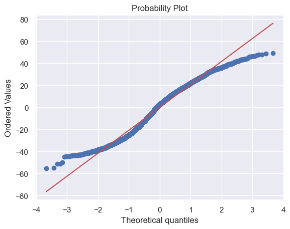

```python
probplot(residuals_model_1['Residuals'], plot = plt)
plt.show()
```

**Observations**

- From both the plots we can clarify that residuals are not normally distributed.

**Constant Variability**

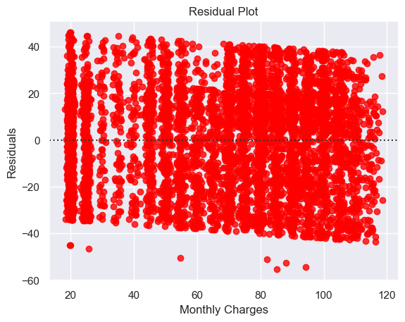

```python
sns.residplot(x_2_train, y_2_train, color = 'red')
plt.title("Residual Plot")
plt.xlabel('Monthly Charges')
plt.ylabel('Residuals')
plt.show()
```

**Observations**

- There is slanting to the right visible in the residual plot.
- This illustrates that the constant variability is not met.

**Conclusion**

Based on the above diagnostics and analysis, we can see that relying on a single feature is insufficient to predict the churn score. We should consider more features that influence the response variable in order to build a better model. Adding more features not only enhances the model's accuracy but also helps in understanding customer behavior. Therefore, we have to consider multiple linear regressions.

**Multiple Linear Regression**

**Model 3**

```python
x_3 = pd.get_dummies(data.drop(columns = ['churn_score']), drop_first = True)
y_3 = data['churn_score']
```

```python
x_3_train, x_3_test, y_3_train, y_3_test = train_test_split(x_3, y_3, test_size = 0.2, random_state = 42)
```

```python
X_3 = sm.add_constant(x_3_train)
model_3 = sm.OLS(y_3_train, X_3).fit()
model_3.summary()
```

OLS Regression Results

| Dep. Variable: | churn_score | R-squared: | 0.133 |
| --- | --- | --- | --- |
| Model: | OLS | Adj. R-squared: | 0.129 |
| Method: | Least Squares | F-statistic: | 33.21 |
| Date: | Thu, 07 Dec 2023 | Prob (F-statistic): | 6.48e-153 |
| Time: | 00:02:04 | Log-Likelihood: | -24910. |
| No. Observations: | 5634 | AIC: | 4.987e+04 |
| Df Residuals: | 5607 | BIC: | 5.005e+04 |
| Df Model: | 26 |  |  |
| Covariance Type: | nonrobust |  |  |

|  | coef | std err | t | P>\|t\| | [0.025 | 0.975] |
| --- | --- | --- | --- | --- | --- | --- |
| const | 5.5377 | 22.903 | 0.242 | 0.809 | -39.360 | 50.436 |
| zip_code | 0.0003 | 0.000 | 0.862 | 0.389 | -0.000 | 0.001 |
| latitude | -0.2598 | 0.318 | -0.817 | 0.414 | -0.883 | 0.364 |
| longitude | -0.1907 | 0.262 | -0.729 | 0.466 | -0.703 | 0.322 |
| tenure_months | -0.0372 | 0.030 | -1.239 | 0.216 | -0.096 | 0.022 |
| monthly_charges | 0.3766 | 0.264 | 1.426 | 0.154 | -0.141 | 0.894 |
| total_charges | -0.0017 | 0.000 | -4.269 | 0.000 | -0.002 | -0.001 |
| gender_Male | 0.0799 | 0.539 | 0.148 | 0.882 | -0.976 | 1.136 |
| senior_citizen_Yes | 1.1792 | 0.777 | 1.517 | 0.129 | -0.344 | 2.703 |
| partner_Yes | 0.5434 | 0.626 | 0.869 | 0.385 | -0.683 | 1.770 |
| dependents_Yes | -4.8057 | 0.713 | -6.736 | 0.000 | -6.204 | -3.407 |
| phone_service_Yes | -0.9783 | 12.419 | -0.079 | 0.937 | -25.325 | 23.368 |
| multiple_lines_No phone service | 6.5161 | 11.071 | 0.589 | 0.556 | -15.187 | 28.219 |
| multiple_lines_Yes | 0.5744 | 1.477 | 0.389 | 0.697 | -2.322 | 3.470 |
| internet_service_Fiber optic | -4.1344 | 6.628 | -0.624 | 0.533 | -17.128 | 8.860 |
| internet_service_No | 0.6764 | 0.957 | 0.707 | 0.480 | -1.199 | 2.552 |
| online_security_No internet service | 0.6764 | 0.957 | 0.707 | 0.480 | -1.199 | 2.552 |
| online_security_Yes | -3.9599 | 1.499 | -2.642 | 0.008 | -6.898 | -1.021 |
| online_backup_No internet service | 0.6764 | 0.957 | 0.707 | 0.480 | -1.199 | 2.552 |
| online_backup_Yes | -1.7595 | 1.476 | -1.192 | 0.233 | -4.653 | 1.134 |
| device_protection_No internet service | 0.6764 | 0.957 | 0.707 | 0.480 | -1.199 | 2.552 |
| device_protection_Yes | -2.6440 | 1.490 | -1.775 | 0.076 | -5.565 | 0.277 |
| tech_support_No internet service | 0.6764 | 0.957 | 0.707 | 0.480 | -1.199 | 2.552 |
| tech_support_Yes | -3.0370 | 1.509 | -2.013 | 0.044 | -5.995 | -0.079 |
| streaming_tv_No internet service | 0.6764 | 0.957 | 0.707 | 0.480 | -1.199 | 2.552 |
| streaming_tv_Yes | -2.3643 | 2.731 | -0.866 | 0.387 | -7.719 | 2.990 |
| streaming_movies_No internet service | 0.6764 | 0.957 | 0.707 | 0.480 | -1.199 | 2.552 |
| streaming_movies_Yes | -1.6289 | 2.721 | -0.599 | 0.549 | -6.964 | 3.706 |
| contract_One year | -3.4668 | 0.841 | -4.123 | 0.000 | -5.115 | -1.818 |
| contract_Two year | -2.7582 | 1.019 | -2.708 | 0.007 | -4.755 | -0.761 |
| paperless_billing_Yes | 1.9432 | 0.600 | 3.241 | 0.001 | 0.768 | 3.119 |
| payment_method_Credit card (automatic) | 0.2868 | 0.815 | 0.352 | 0.725 | -1.311 | 1.885 |
| payment_method_Electronic check | 1.9919 | 0.800 | 2.488 | 0.013 | 0.423 | 3.561 |
| payment_method_Mailed check | 0.2158 | 0.868 | 0.249 | 0.804 | -1.486 | 1.918 |

| Omnibus: | 566.503 | Durbin-Watson: | 1.993 |
| --- | --- | --- | --- |
| Prob(Omnibus): | 0.000 | Jarque-Bera (JB): | 205.124 |
| Skew: | -0.225 | Prob(JB): | 2.87e-45 |
| Kurtosis: | 2.181 | Cond. No. | 1.00e+16 |

Notes:  
[1] Standard Errors assume that the covariance matrix of the errors is correctly specified.  
[2] The smallest eigenvalue is 4.92e-19. This might indicate that there are  
strong multicollinearity problems or that the design matrix is singular.

$\text{Churn Score} = 5.5377 + 0.0003 \times \text{zip_code} - 0.2598 \times \text{latitude} - 0.1907 \times \text{longitude} - 0.0372 \times \text{tenure_months} + 0.3766 \times \text{monthly_charges} - 0.0017 \times \text{total_charges} + 0.0799 \times \text{gender_Male} + 1.1792 \times \text{senior_citizen_Yes} + 0.5434 \times \text{partner_Yes} - 4.8057 \times \text{dependents_Yes} + (-0.9783) \times \text{phone_service_Yes} + 6.5161 \times \text{multiple_lines_No_phone_service} + 0.5744 \times \text{multiple_lines_Yes} - 4.1344 \times \text{internet_service_Fiber_optic} + 0.6764 \times \text{internet_service_No} + (-3.9599) \times \text{online_security_Yes} + (-1.7595) \times \text{online_backup_Yes} + (-2.6440) \times \text{device_protection_Yes} + (-3.0370) \times \text{tech_support_Yes} + (-2.3643) \times \text{streaming_tv_Yes} + (-1.6289) \times \text{streaming_movies_Yes} + (-3.4668) \times \text{contract_One_year} + (-2.7582) \times \text{contract_Two_year} + 1.9432 \times \text{paperless_billing_Yes} + 0.2868 \times \text{payment_method_Credit_card_(automatic)} + 1.9919 \times \text{payment_method_Electronic_check} + 0.2158 \times \text{payment_method_Mailed_check}$

**Intercept**

- The intercept represents the value of the dependent variable when all independent variables are set to zero. So in this case, 5.5377 is set as a base value by the model.
- The intercept is meaningful considering last models beacuse the value is very less and hence there are multiple features.

**Model Assessment**

```python
model_3_metrics = pd.DataFrame({
    "MSE" : [mean_squared_error(y_3_train, model_3.predict(sm.add_constant(x_3_train))), mean_squared_error(y_3_test, model_3.predict(sm.add_constant(x_3_test)))],
    "RMSE" : [(mean_squared_error(y_3_train, model_3.predict(sm.add_constant(x_3_train))))**0.5, (mean_squared_error(y_3_test, model_3.predict(sm.add_constant(x_3_test))))**0.5],
    "R^2" : [r2_score(y_3_train, model_3.predict(sm.add_constant(x_3_train))), r2_score(y_3_test, model_3.predict(sm.add_constant(x_3_test)))],
    "MAE" : [mean_absolute_error(y_3_train, model_3.predict(sm.add_constant(x_3_train))), mean_absolute_error(y_3_test, model_3.predict(sm.add_constant(x_3_test)))]
}, index = ["Train", "Test"]).T

model_3_metrics
```

|  | Train | Test |
| --- | --- | --- |
| MSE | 405.425701 | 389.921557 |
| RMSE | 20.135186 | 19.746432 |
| R^2 | 0.133460 | 0.120148 |
| MAE | 16.908589 | 16.404714 |

**Observations**

- The model has shown some improvement compared to the last two models. The errors are slightly lower, indicating a better fit to the data.
- The $R^2$ is still low but has increased compared to the last models, suggesting that the model explains a larger portion of the variance in the target variable compared to the last ones.
- The metric we choose here is $R^2$.
- The $R^2$ is not pretty much good but is better than the last two models.
- The model may perform better if we do backward feature selection.

**Model Diagnostics**

```python
residuals_model_3 = pd.DataFrame({'Actual': y_3_train,
                               'Predicted': model_3.fittedvalues,
                               'Residuals': model_3.resid})

residuals_model_3.reset_index(drop = True, inplace = True)
residuals_model_3.head(10)
```

|  | Actual | Predicted | Residuals |
| --- | --- | --- | --- |
| 0 | 28 | 56.181697 | -28.181697 |
| 1 | 75 | 68.253096 | 6.746904 |
| 2 | 60 | 63.310837 | -3.310837 |
| 3 | 85 | 63.850533 | 21.149467 |
| 4 | 43 | 50.239811 | -7.239811 |
| 5 | 77 | 72.859882 | 4.140118 |
| 6 | 73 | 51.143120 | 21.856880 |
| 7 | 20 | 53.272938 | -33.272938 |
| 8 | 77 | 56.251609 | 20.748391 |
| 9 | 46 | 49.057936 | -3.057936 |

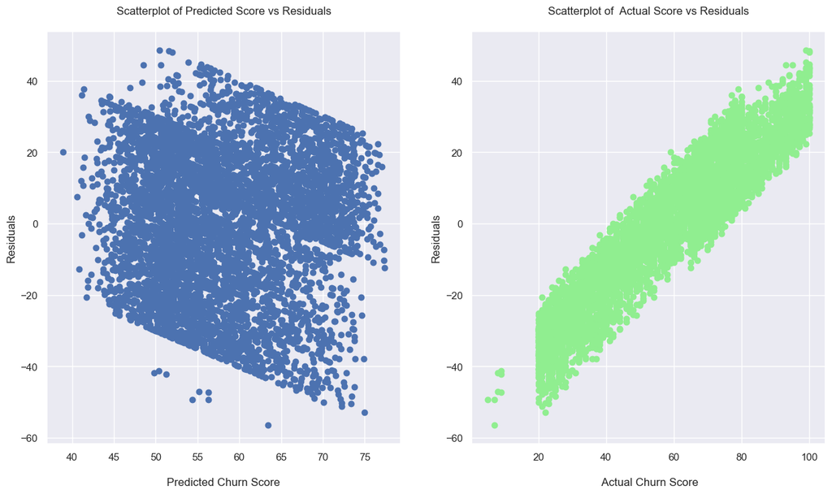

```python
fig, (ax1, ax2) = plt.subplots(nrows = 1, ncols = 2, figsize = (15,8))
ax1.scatter(residuals_model_3['Predicted'], residuals_model_3['Residuals'])
ax1.set_title("Scatterplot of Predicted Score vs Residuals\n")
ax1.set_xlabel("\nPredicted Churn Score")
ax1.set_ylabel("Residuals")

ax2.scatter(residuals_model_3['Actual'], residuals_model_3['Residuals'], color = 'lightgreen')
ax2.set_title("Scatterplot of  Actual Score vs Residuals\n")
ax2.set_xlabel("\n Actual Churn Score")
ax2.set_ylabel("Residuals")

plt.show()
```

**Observations**

- The residuals are showing a banding pattern for Predicted Churn Score. This pattern indicates that the constant variability condition is not met.
- The model overestimates lower churn score and underestimates higher churn score values.

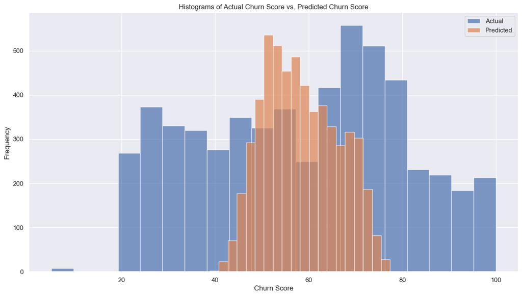

```python
plt.figure(figsize = (15,8))
plt.hist(residuals_model_3['Actual'], label = 'Actual', bins = 20, alpha = 0.7);
plt.hist(residuals_model_3['Predicted'], label = 'Predicted', bins = 20, alpha = 0.7);
plt.xlabel('Churn Score');
plt.ylabel('Frequency');
plt.title('Histograms of Actual Churn Score vs. Predicted Churn Score')
plt.legend()
plt.show()
```

**Observations**

- The distribution of both plots are entirely different.
- The model predictions are highly clustered around 40 to 80.

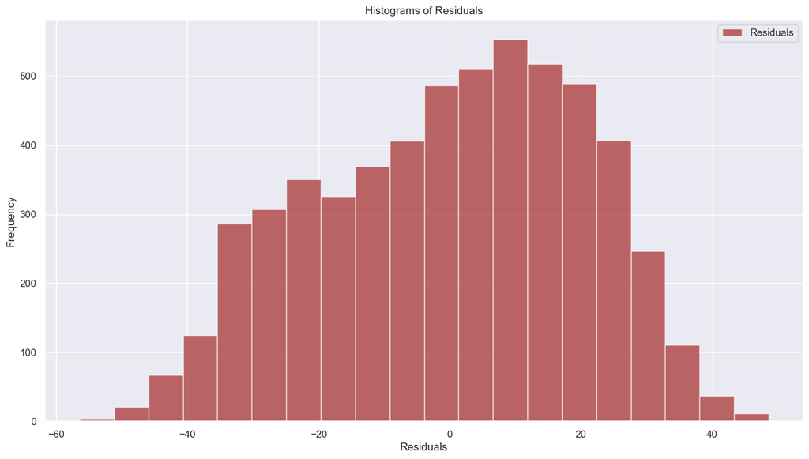

```python
plt.figure(figsize = (15,8))
plt.hist(residuals_model_3['Residuals'], label = 'Residuals', bins = 20, alpha = 0.7, color = 'brown');
plt.xlabel('Residuals');
plt.ylabel('Frequency');
plt.title('Histograms of Residuals')
plt.legend()
plt.show()
```

**Observations**

- The residuals are nearly normally distibuted.

**Model 4**

**Backward Feature Selection**

```python
# Changing column values appropriate for statsmodels formula string

def replacex(col):
    data[col] = [i.replace(' ', '_') for i in data[col]]
    return data[col]

for i in data.dtypes[data.dtypes=='object'].index:
    data[i] = replacex(i)

def change():
    z = []
    for i in data['contract']:
        if i == 'Month-to-month':
            z.append(i.replace('-', '_'))
        else:
            z.append(i)
    return z

data['contract'] = change()

def change_automatic():
    x = []
    for i in data['payment_method']:
        x.append(i.strip("_(automatic)"))
    return x

data['payment_method'] = change_automatic()
```

```python
# Encoding the data [One-Hot Encoding]
data_encoded = pd.get_dummies(data, drop_first = True)

# Creating intial formula string
formula_string_indep_vars_encoded = ' + '.join(data_encoded.drop(columns = 'churn_score').columns)
formula_string_encoded = 'churn_score ~ ' + formula_string_indep_vars_encoded
```

```python
# Eliminating features with p-values > 0.05.
telcom_temp_df = data_encoded.copy()

i = 1

removed_columns = []

while i >= 0.05:
    model = sm.formula.ols(formula = formula_string_encoded, data = telcom_temp_df).fit()

    try:
        col = model.pvalues[model.pvalues >= 0.05].sort_values(ascending = False).index[0]
    except IndexError:
        break

    removed_columns.append(col)

    formula_string_encoded = ' + '.join(telcom_temp_df.drop(columns = ['churn_score', col]).columns)
    formula_string_encoded = 'churn_score ~ ' + formula_string_encoded

    telcom_temp_df = telcom_temp_df.drop(columns = [col])

print(formula_string_encoded)
```

```
churn_score ~ monthly_charges + total_charges + dependents_Yes + phone_service_Yes + multiple_lines_No_phone_service + multiple_lines_Yes + online_security_Yes + device_protection_Yes + tech_support_Yes + contract_One_year + contract_Two_year + paperless_billing_Yes + payment_method_Electronic_check
```

```python
# Model building
x_4 = telcom_temp_df.drop(columns = ['churn_score'])
y_4 = telcom_temp_df['churn_score']
```

```python
x_4_train, x_4_test, y_4_train, y_4_test = train_test_split(x_4, y_4, test_size = 0.2, random_state = 42)
```

```python
X_4 = sm.add_constant(x_4_train)
model_4 = sm.OLS(y_4_train, X_4).fit()
model_4.summary()
```

OLS Regression Results

| Dep. Variable: | churn_score | R-squared: | 0.132 |
| --- | --- | --- | --- |
| Model: | OLS | Adj. R-squared: | 0.130 |
| Method: | Least Squares | F-statistic: | 71.21 |
| Date: | Thu, 07 Dec 2023 | Prob (F-statistic): | 1.07e-162 |
| Time: | 00:17:03 | Log-Likelihood: | -24915. |
| No. Observations: | 5634 | AIC: | 4.986e+04 |
| Df Residuals: | 5621 | BIC: | 4.994e+04 |
| Df Model: | 12 |  |  |
| Covariance Type: | nonrobust |  |  |

|  | coef | std err | t | P>\|t\| | [0.025 | 0.975] |
| --- | --- | --- | --- | --- | --- | --- |
| const | 35.8808 | 0.598 | 59.956 | 0.000 | 34.708 | 37.054 |
| monthly_charges | 0.2052 | 0.017 | 11.915 | 0.000 | 0.171 | 0.239 |
| total_charges | -0.0021 | 0.000 | -9.346 | 0.000 | -0.002 | -0.002 |
| dependents_Yes | -4.7557 | 0.660 | -7.205 | 0.000 | -6.050 | -3.462 |
| phone_service_Yes | 16.1816 | 0.535 | 30.268 | 0.000 | 15.134 | 17.230 |
| multiple_lines_No_phone_service | 19.6991 | 0.637 | 30.944 | 0.000 | 18.451 | 20.947 |
| multiple_lines_Yes | 1.4947 | 0.668 | 2.236 | 0.025 | 0.184 | 2.805 |
| online_security_Yes | -3.1861 | 0.686 | -4.645 | 0.000 | -4.531 | -1.842 |
| device_protection_Yes | -1.7831 | 0.708 | -2.517 | 0.012 | -3.172 | -0.394 |
| tech_support_Yes | -2.3260 | 0.704 | -3.306 | 0.001 | -3.705 | -0.947 |
| contract_One_year | -3.7759 | 0.800 | -4.719 | 0.000 | -5.344 | -2.207 |
| contract_Two_year | -3.2906 | 0.903 | -3.646 | 0.000 | -5.060 | -1.521 |
| paperless_billing_Yes | 1.9256 | 0.597 | 3.223 | 0.001 | 0.755 | 3.097 |
| payment_method_Electronic_check | 1.8964 | 0.649 | 2.921 | 0.004 | 0.624 | 3.169 |

| Omnibus: | 569.268 | Durbin-Watson: | 1.997 |
| --- | --- | --- | --- |
| Prob(Omnibus): | 0.000 | Jarque-Bera (JB): | 204.363 |
| Skew: | -0.222 | Prob(JB): | 4.20e-45 |
| Kurtosis: | 2.179 | Cond. No. | 4.84e+19 |

Notes:  
[1] Standard Errors assume that the covariance matrix of the errors is correctly specified.  
[2] The smallest eigenvalue is 2.48e-29. This might indicate that there are  
strong multicollinearity problems or that the design matrix is singular.

$ \text{Churn Score} = 35.8808 + 0.2052 \times \text{monthly_charges} - 0.0021 \times \text{total_charges} - 4.7557 \times \text{dependents_Yes} + 16.1816 \times \text{phone_service_Yes} + 19.6991 \times \text{multiple_lines_No_phone_service} + 1.4947 \times \text{multiple_lines_Yes} - 3.1861 \times \text{online_security_Yes} - 1.7831 \times \text{device_protection_Yes} - 2.3260 \times \text{tech_support_Yes} - 3.7759 \times \text{contract_One_year} - 3.2906 \times \text{contract_Two_year} + 1.9256 \times \text{paperless_billing_Yes} + 1.8964 \times \text{payment_method_Electronic_check} $

**Model Assessment**

```python
model_4_metrics = pd.DataFrame({
    "MSE" : [mean_squared_error(y_4_train, model_4.predict(sm.add_constant(x_4_train))), mean_squared_error(y_4_test, model_4.predict(sm.add_constant(x_4_test)))],
    "RMSE" : [(mean_squared_error(y_4_train, model_4.predict(sm.add_constant(x_4_train))))**0.5, (mean_squared_error(y_4_test, model_4.predict(sm.add_constant(x_4_test))))**0.5],
    "R^2" : [r2_score(y_4_train, model_4.predict(sm.add_constant(x_4_train))), r2_score(y_4_test, model_4.predict(sm.add_constant(x_4_test)))],
    "MAE" : [mean_absolute_error(y_4_train, model_4.predict(sm.add_constant(x_4_train))), mean_absolute_error(y_4_test, model_4.predict(sm.add_constant(x_4_test)))]
}, index = ["Train", "Test"]).T

model_4_metrics
```

|  | Train | Test |
| --- | --- | --- |
| MSE | 406.123845 | 389.815212 |
| RMSE | 20.152515 | 19.743739 |
| R^2 | 0.131967 | 0.120388 |
| MAE | 16.924102 | 16.412330 |

**Observations**

- There is no significant change seen in the model even after backward selection.
- This suggests that may be non - linear models result in better outcomes.
- The metric we choose here is $R^2$.
- The $R^2$ is similar to the last model that is the one build with all the features.

**Model Diagnostics**

```python
residuals_model_4 = pd.DataFrame({'Actual': y_4_train,
                               'Predicted': model_4.fittedvalues,
                               'Residuals': model_4.resid})
residuals_model_4.head(10)
```

|  | Actual | Predicted | Residuals |
| --- | --- | --- | --- |
| 2142 | 28 | 55.776847 | -27.776847 |
| 1623 | 75 | 68.074818 | 6.925182 |
| 6074 | 60 | 64.211398 | -4.211398 |
| 1362 | 85 | 62.134065 | 22.865935 |
| 6754 | 43 | 50.581357 | -7.581357 |
| 1212 | 77 | 72.535710 | 4.464290 |
| 2722 | 73 | 51.388192 | 21.611808 |
| 4006 | 20 | 52.802203 | -32.802203 |
| 6791 | 77 | 57.117229 | 19.882771 |
| 5466 | 46 | 49.672665 | -3.672665 |

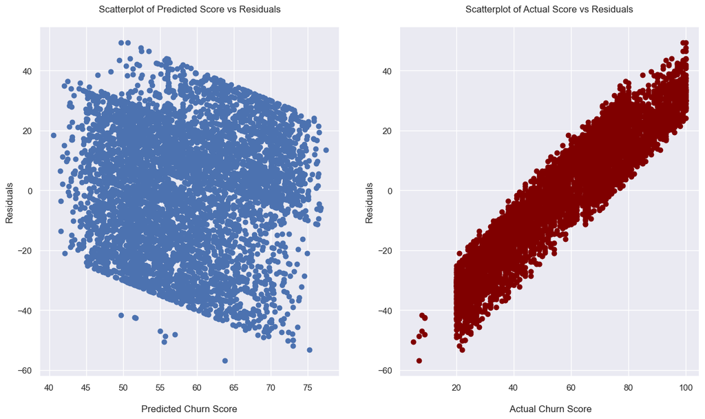

```python
fig, (ax1, ax2) = plt.subplots(nrows = 1, ncols = 2, figsize = (15,8))
ax1.scatter(residuals_model_4['Predicted'], residuals_model_4['Residuals'])
ax1.set_title("Scatterplot of Predicted Score vs Residuals\n")
ax1.set_xlabel("\nPredicted Churn Score")
ax1.set_ylabel("Residuals")

ax2.scatter(residuals_model_4['Actual'], residuals_model_4['Residuals'], color = 'maroon')
ax2.set_title("Scatterplot of Actual Score vs Residuals\n ")
ax2.set_xlabel("\n Actual Churn Score")
ax2.set_ylabel("Residuals")

plt.show()
```

**Observations**

- The residuals are showing a banding pattern for Predicted Churn Score. This pattern indicates that the constant variability condition is not met.
- The model overestimates lower churn score and underestimates higher churn score values.

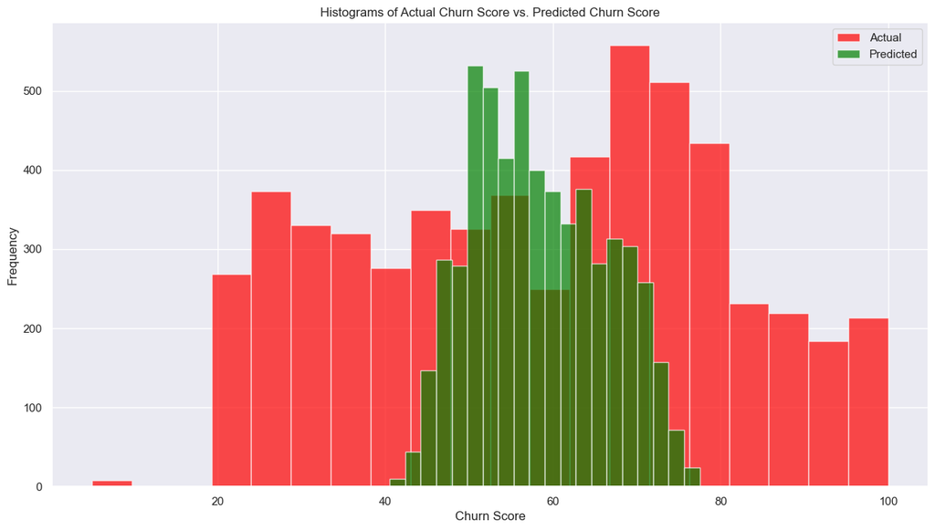

```python
plt.figure(figsize = (15,8))
plt.hist(residuals_model_4['Actual'], label = 'Actual', bins = 20, alpha = 0.7, color = 'red')
plt.hist(residuals_model_4['Predicted'], label = 'Predicted', bins = 20, alpha = 0.7, color = 'green')
plt.xlabel('Churn Score');
plt.ylabel('Frequency');
plt.title('Histograms of Actual Churn Score vs. Predicted Churn Score')
plt.legend()
plt.show()
```

**Observations**

- The distribution of both plots are entirely different.
- The model predictions are highly clustered around 40 to 80.

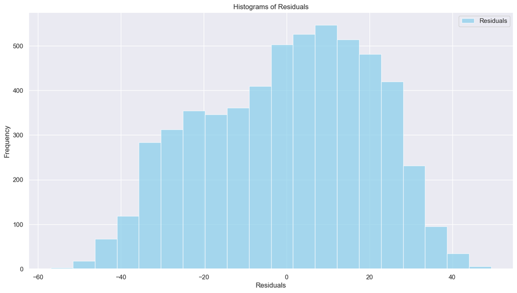

```python
plt.figure(figsize = (15,8))
plt.hist(residuals_model_4['Residuals'], label = 'Residuals', bins = 20, alpha = 0.7, color = 'skyblue');
plt.xlabel('Residuals');
plt.ylabel('Frequency');
plt.title('Histograms of Residuals')
plt.legend()
plt.show()
```

**Observations**

- The residuals are nearly normally distibuted.

**Non - Linear Regression**

**Model 5**

```python
telcom_temp_df['monthly_charges^3'] = np.power(telcom_temp_df['monthly_charges'], 3)
telcom_temp_df['total_charges^2'] = np.power(telcom_temp_df['total_charges'], 2)

telcom_temp_df.drop(columns = ['monthly_charges', 'total_charges'], inplace = True)
```

```python
non_linear_formula_string = "churn_score ~ np.power(monthly_charges, 3) + np.power(total_charges, 2) + dependents_Yes + phone_service_Yes + multiple_lines_No_phone_service + multiple_lines_Yes + online_security_Yes + device_protection_Yes + tech_support_Yes + contract_One_year + contract_Two_year + paperless_billing_Yes + payment_method_Electronic_check"
print(non_linear_formula_string)
```

[output not shown]

```python
x_5 = telcom_temp_df.drop(columns = ['churn_score'])
y_5 = telcom_temp_df['churn_score']
```

```python
x_5_train, x_5_test, y_5_train, y_5_test = train_test_split(x_5, y_5, test_size = 0.2, random_state = 42)
```

```python
X_5 = sm.add_constant(x_5_train)
model_5 = sm.OLS(y_5_train, X_5).fit()
model_5.summary()
```

OLS Regression Results

| Dep. Variable: | churn_score | R-squared: | 0.124 |
| --- | --- | --- | --- |
| Model: | OLS | Adj. R-squared: | 0.122 |
| Method: | Least Squares | F-statistic: | 66.28 |
| Date: | Thu, 07 Dec 2023 | Prob (F-statistic): | 1.29e-151 |
| Time: | 00:59:55 | Log-Likelihood: | -24941. |
| No. Observations: | 5634 | AIC: | 4.991e+04 |
| Df Residuals: | 5621 | BIC: | 4.999e+04 |
| Df Model: | 12 |  |  |
| Covariance Type: | nonrobust |  |  |

|  | coef | std err | t | P>\|t\| | [0.025 | 0.975] |
| --- | --- | --- | --- | --- | --- | --- |
| const | 39.7306 | 0.496 | 80.152 | 0.000 | 38.759 | 40.702 |
| dependents_Yes | -5.1239 | 0.661 | -7.751 | 0.000 | -6.420 | -3.828 |
| phone_service_Yes | 18.4309 | 0.449 | 41.046 | 0.000 | 17.551 | 19.311 |
| multiple_lines_No_phone_service | 21.2997 | 0.661 | 32.236 | 0.000 | 20.004 | 22.595 |
| multiple_lines_Yes | 1.0476 | 0.661 | 1.584 | 0.113 | -0.249 | 2.344 |
| online_security_Yes | -2.5416 | 0.674 | -3.770 | 0.000 | -3.863 | -1.220 |
| device_protection_Yes | -1.6974 | 0.697 | -2.437 | 0.015 | -3.063 | -0.332 |
| tech_support_Yes | -1.6795 | 0.692 | -2.428 | 0.015 | -3.035 | -0.324 |
| contract_One_year | -5.6605 | 0.765 | -7.403 | 0.000 | -7.159 | -4.161 |
| contract_Two_year | -5.6557 | 0.852 | -6.634 | 0.000 | -7.327 | -3.984 |
| paperless_billing_Yes | 2.2607 | 0.593 | 3.810 | 0.000 | 1.098 | 3.424 |
| payment_method_Electronic_check | 2.5022 | 0.644 | 3.886 | 0.000 | 1.240 | 3.764 |
| monthly_charges^3 | 1.226e-05 | 1.25e-06 | 9.831 | 0.000 | 9.82e-06 | 1.47e-05 |
| total_charges^2 | -2.374e-07 | 3.06e-08 | -7.746 | 0.000 | -2.97e-07 | -1.77e-07 |

| Omnibus: | 623.837 | Durbin-Watson: | 2.001 |
| --- | --- | --- | --- |
| Prob(Omnibus): | 0.000 | Jarque-Bera (JB): | 214.753 |
| Skew: | -0.228 | Prob(JB): | 2.33e-47 |
| Kurtosis: | 2.159 | Cond. No. | 1.50e+20 |

Notes:  
[1] Standard Errors assume that the covariance matrix of the errors is correctly specified.  
[2] The smallest eigenvalue is 9.01e-23. This might indicate that there are  
strong multicollinearity problems or that the design matrix is singular.

**Model Assessment**

```python
model_5_metrics = pd.DataFrame({
    "MSE" : [mean_squared_error(y_5_train, model_5.predict(sm.add_constant(x_5_train))), mean_squared_error(y_5_test, model_5.predict(sm.add_constant(x_5_test)))],
    "RMSE" : [(mean_squared_error(y_5_train, model_5.predict(sm.add_constant(x_5_train))))**0.5, (mean_squared_error(y_5_test, model_5.predict(sm.add_constant(x_5_test))))**0.5],
    "R^2" : [r2_score(y_5_train, model_5.predict(sm.add_constant(x_5_train))), r2_score(y_5_test, model_5.predict(sm.add_constant(x_5_test)))],
    "MAE" : [mean_absolute_error(y_5_train, model_5.predict(sm.add_constant(x_5_train))), mean_absolute_error(y_5_test, model_5.predict(sm.add_constant(x_5_test)))]
}, index = ["Train", "Test"]).T

model_5_metrics
```

|  | Train | Test |
| --- | --- | --- |
| MSE | 409.873359 | 389.600180 |
| RMSE | 20.245329 | 19.738292 |
| R^2 | 0.123953 | 0.120873 |
| MAE | 17.018089 | 16.450255 |

**Observations**

- The metrics doesn't have a significant change even after using a non - linear approach.
- The metric we choose here is $R^2$.
- Even after switching to non - linear there is no increase to be seen in the $R^2$ value. This indicates that these features are not enough in predicting the churn score.

**Model Diagnostics**

```python
residuals_model_5 = pd.DataFrame({'Actual': y_5_train,
                               'Predicted': model_5.fittedvalues,
                               'Residuals': model_5.resid})
residuals_model_5.head(10)
```

|  | Actual | Predicted | Residuals |
| --- | --- | --- | --- |
| 2142 | 28 | 54.377075 | -26.377075 |
| 1623 | 75 | 68.066127 | 6.933873 |
| 6074 | 60 | 65.156647 | -5.156647 |
| 1362 | 85 | 62.210746 | 22.789254 |
| 6754 | 43 | 53.097362 | -10.097362 |
| 1212 | 77 | 69.254450 | 7.745550 |
| 2722 | 73 | 51.021789 | 21.978211 |
| 4006 | 20 | 54.735518 | -34.735518 |
| 6791 | 77 | 58.385749 | 18.614251 |
| 5466 | 46 | 48.782907 | -2.782907 |

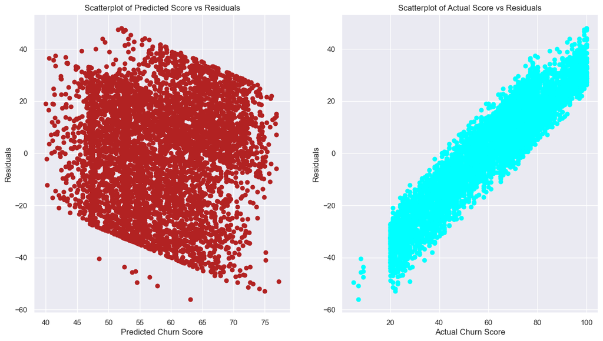

```python
fig, (ax1, ax2) = plt.subplots(nrows = 1, ncols = 2, figsize = (15,8))
ax1.scatter(residuals_model_5['Predicted'], residuals_model_5['Residuals'], color = 'firebrick')
ax1.set_title("Scatterplot of Predicted Score vs Residuals")
ax1.set_xlabel("Predicted Churn Score")
ax1.set_ylabel("Residuals")

ax2.scatter(residuals_model_5['Actual'], residuals_model_5['Residuals'], color = 'aqua')
ax2.set_title("Scatterplot of Actual Score vs Residuals")
ax2.set_xlabel("Actual Churn Score")
ax2.set_ylabel("Residuals")

plt.show()
```

**Observations**

- The residuals are showing a banding pattern for Predicted Churn Score. This pattern indicates that the constant variability condition is not met.
- The model overestimates lower churn score and underestimates higher churn score values.

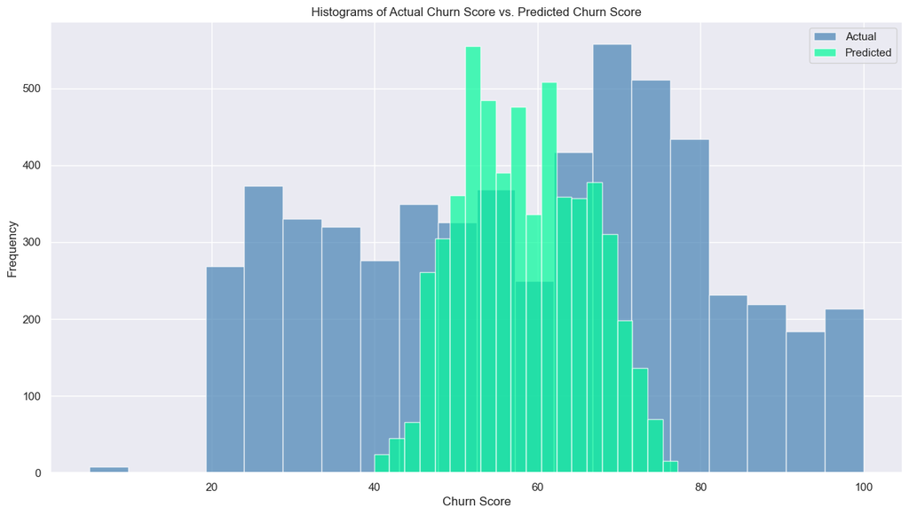

```python
plt.figure(figsize = (15,8))
plt.hist(residuals_model_5['Actual'], label = 'Actual', bins = 20, alpha = 0.7, color = 'steelblue')
plt.hist(residuals_model_5['Predicted'], label = 'Predicted', bins = 20, alpha = 0.7, color = 'mediumspringgreen')
plt.xlabel('Churn Score');
plt.ylabel('Frequency');
plt.title('Histograms of Actual Churn Score vs. Predicted Churn Score')
plt.legend()
plt.show()
```

**Observations**

- The distribution of both plots are entirely different.
- The model predictions are highly clustered around 40 to 80.

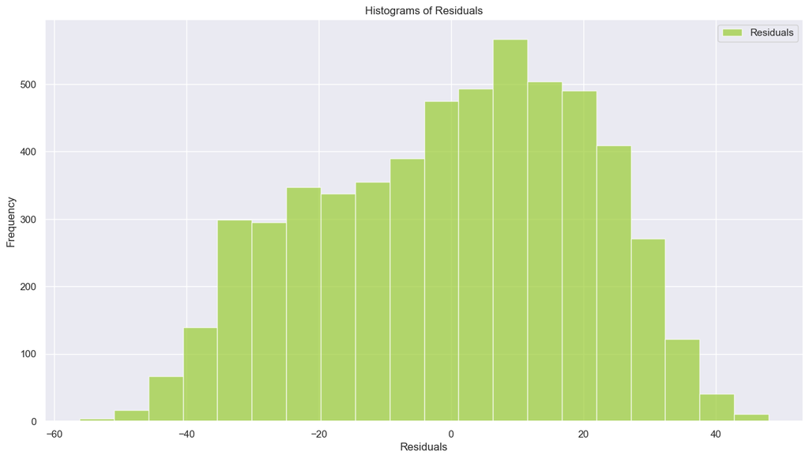

```python
plt.figure(figsize = (15,8))
plt.hist(residuals_model_5['Residuals'], label = 'Residuals', bins = 20, alpha = 0.7, color = 'yellowgreen');
plt.xlabel('Residuals');
plt.ylabel('Frequency');
plt.title('Histograms of Residuals')
plt.legend()
plt.show()
```

**Observations**

- The residuals are nearly normally distibuted.

**Conclusion**

- The five models, including linear and non-linear approaches, did not result in a significant improvement in predicting churn score.
- The $R^2$ values across models are relatively low, indicating that the models explain only a small portion of the variance in the target variable.
- The features considered in these models may not be sufficient to capture the complexities of the underlying patterns, and hence more features may be necessary for a better model building.